# Project 2 - Alon Goodman & Ran Hassid

# Q1

```r
#install.packages("igraph")
library(igraph)
```

### The System

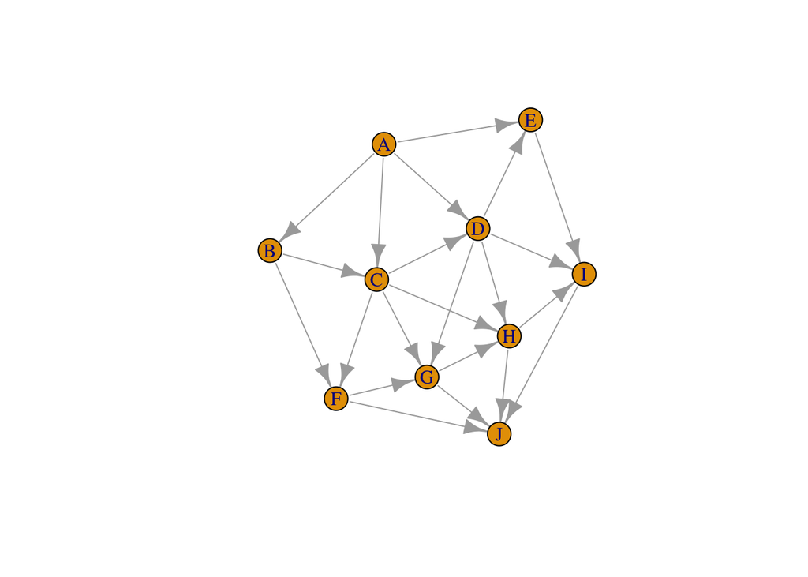

## a

The distribution of the time of until an edge will not working is exp(theta).

So, the probability that an edge will not work after 10 days:

P(exp(theta)<10) = 1 - e^(-10 * theta)

```r
theta <- 0.02

h_x.result_vec.a <- numeric(15000)

for (i in 1:15000) {
  graph.zero_day.i <- make_graph(c("A", "B", "A", "C","A", "D","A", "E",
                           "B","C","B","F",
                           "C","F","C","G","C","D","C","H",
                           "D","E","D","H","D","I","D","G",
                           "E","I",
                           "F","G","F","J",
                           "G","H","G","J",
                           "H","I","H","J",
                           "I","J"), directed = TRUE)
  after_10_days.i <- rbinom(n = 22,size = 1,prob = 1-exp(-10*theta))
  graph_after_10_days.i <- delete.edges(graph = graph.zero_day.i,edges = which(after_10_days.i==1))
  paths_A_J_after_10_days.i <- all_simple_paths(graph = graph_after_10_days.i,from = "A","J")
  if(identical(paths_A_J_after_10_days.i,list())){
    h_x.result_vec.a[i] <- 1
  }

}
```

```
## Expected value estimator = 0.0045
## Varinace estimator = 0.0044
```

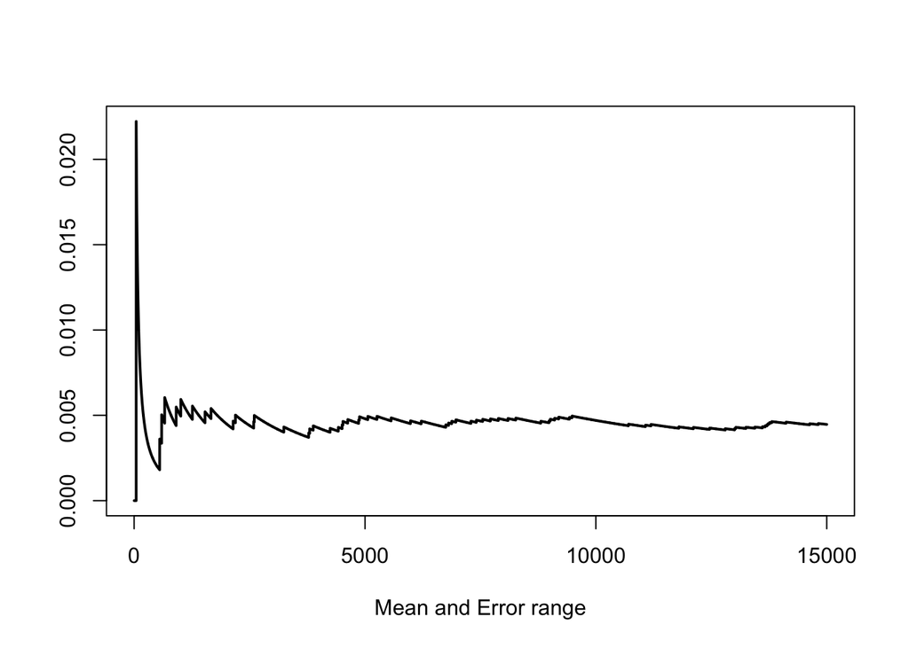

```r
est.int <- cumsum(h_x.result_vec.a)/(1:15000)
est.err <- sqrt( cumsum( (h_x.result_vec.a-est.int)^2 )) / (1:15000)

plot(est.int, xlab = "Mean and Error range", ylab = "", type = "l", lwd = 2)
```

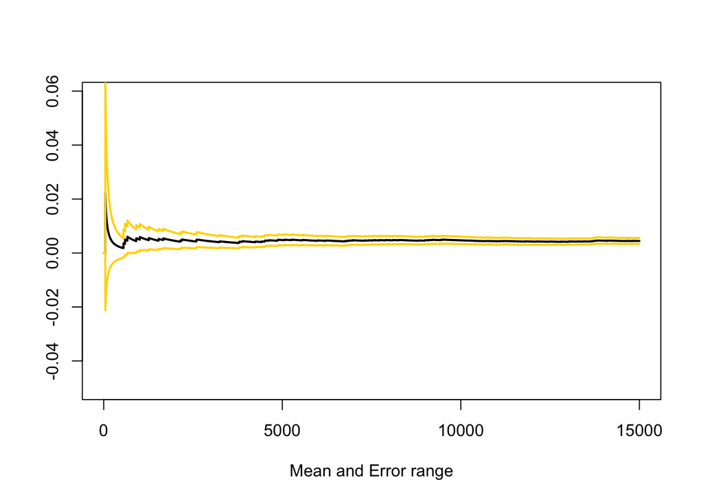

```r
plot(est.int, xlab = "Mean and Error range", ylab = "", type = "l", lwd = 2, ylim = mean(h_x.result_vec.a)+100*est.err[15000]*c(-1,1))
lines(est.int + 2*est.err, col = "gold", lwd = 2)
lines(est.int - 2*est.err, col = "gold", lwd = 2)
```

## b

```r
theta <- 0.005

h_x.result_vec.b <- numeric(50000)

for (i in 1:50000) {
  graph.zero_day.i <- make_graph(c("A", "B", "A", "C","A", "D","A", "E",
                           "B","C","B","F",
                           "C","F","C","G","C","D","C","H",
                           "D","E","D","H","D","I","D","G",
                           "E","I",
                           "F","G","F","J",
                           "G","H","G","J",
                           "H","I","H","J",
                           "I","J"), directed = TRUE)
  after_10_days.i <- rbinom(n = 22,size = 1,prob = 1-exp(-10*theta))
  graph_after_10_days.i <- delete.edges(graph = graph.zero_day.i,edges = which(after_10_days.i==1))
  paths_A_J_after_10_days.i <- all_simple_paths(graph = graph_after_10_days.i,from = "A","J")
  if(identical(paths_A_J_after_10_days.i,list())){
    h_x.result_vec.b[i] <- 1
  }

}
```

```
## Expected value estimator = 4e-05
## Varinace estimator = 3.99991999839997e-05
## Out of 50,000 test, the no. of failures = 2
```

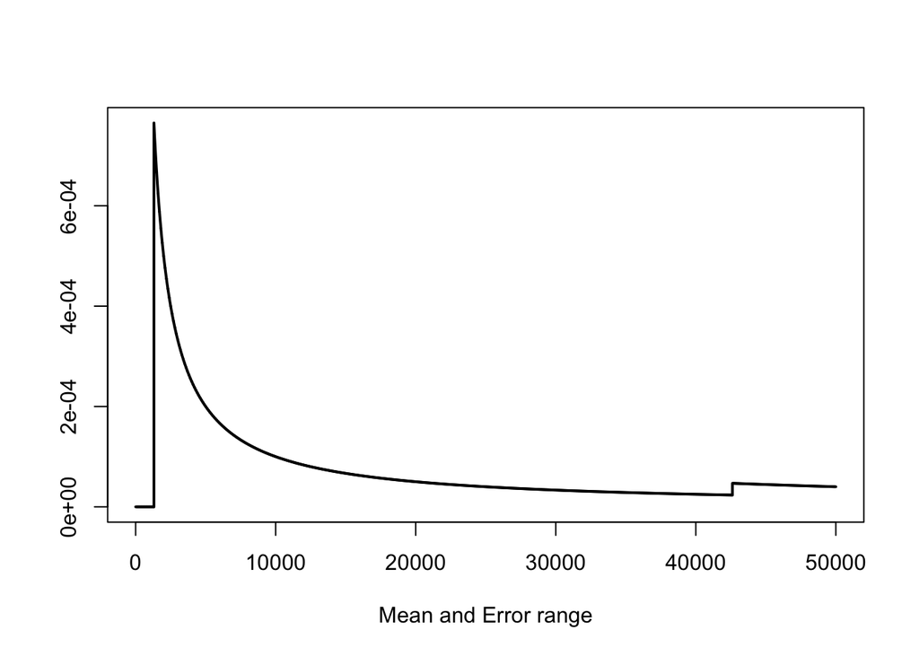

```r
est.int <- cumsum(h_x.result_vec.b)/(1:50000)
est.err <- sqrt( cumsum( (h_x.result_vec.b-est.int)^2 )) / (1:50000)

plot(est.int, xlab = "Mean and Error range", ylab = "", type = "l", lwd = 2)
```

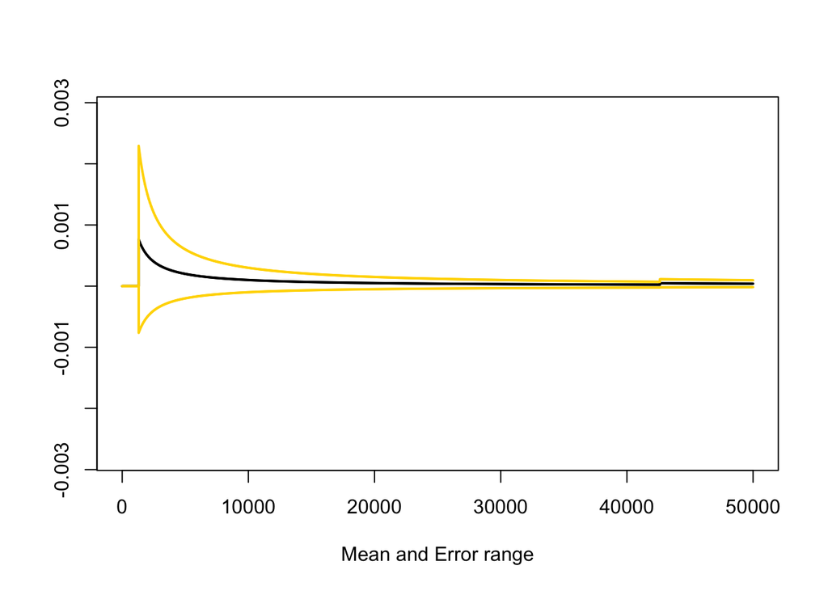

```r
plot(est.int, xlab = "Mean and Error range", ylab = "", type = "l", lwd = 2, ylim = mean(h_x.result_vec.b)+100*est.err[50000]*c(-1,1))
lines(est.int + 2*est.err, col = "gold", lwd = 2)
lines(est.int - 2*est.err, col = "gold", lwd = 2)
```

## c

```r
theta.f <- 0.02
theta.g <- 0.05

h_x.result_vec.c <- numeric(15000)

for (i in 1:15000) {
  graph.zero_day.i <- make_graph(c("A", "B", "A", "C","A", "D","A", "E",
                           "B","C","B","F",
                           "C","F","C","G","C","D","C","H",
                           "D","E","D","H","D","I","D","G",
                           "E","I",
                           "F","G","F","J",
                           "G","H","G","J",
                           "H","I","H","J",
                           "I","J"), directed = TRUE)
  after_10_days.i <- rbinom(n = 22,size = 1,prob = 1-exp(-10*theta.g))
  graph_after_10_days.i <- delete.edges(graph = graph.zero_day.i,edges = which(after_10_days.i==1))
  paths_A_J_after_10_days.i <- all_simple_paths(graph = graph_after_10_days.i,from = "A","J")
  if(identical(paths_A_J_after_10_days.i,list())){
    h_x.result_vec.c[i] <- 1*prod( dbinom(x = after_10_days.i,size = 1,prob = 1-exp(-10*theta.f)) / dbinom(x = after_10_days.i,size = 1,prob = 1-exp(-10*theta.g)))
  }

}
```

```
## Expected value estimator = 0.0046
## Varinace estimator = 0.0024
```

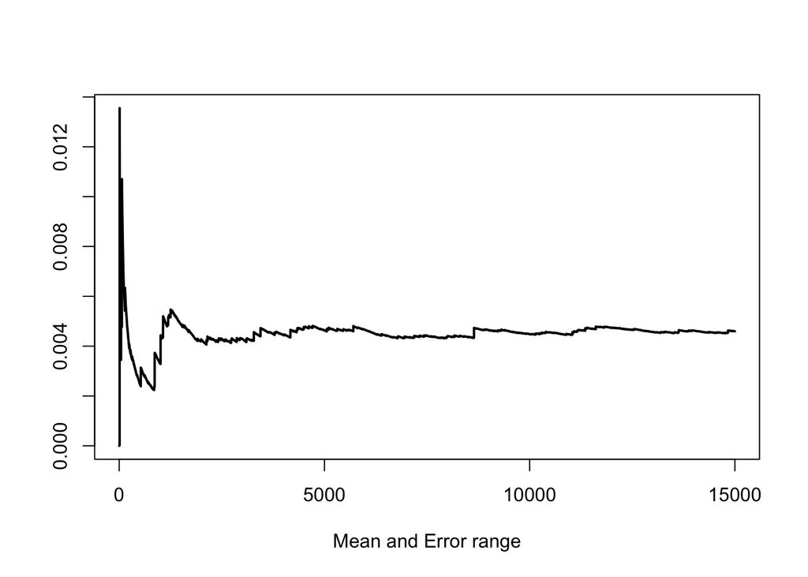

```r
est.int <- cumsum(h_x.result_vec.c)/(1:15000)
est.err <- sqrt( cumsum( (h_x.result_vec.c-est.int)^2 )) / (1:15000)

plot(est.int, xlab = "Mean and Error range", ylab = "", type = "l", lwd = 2)
```

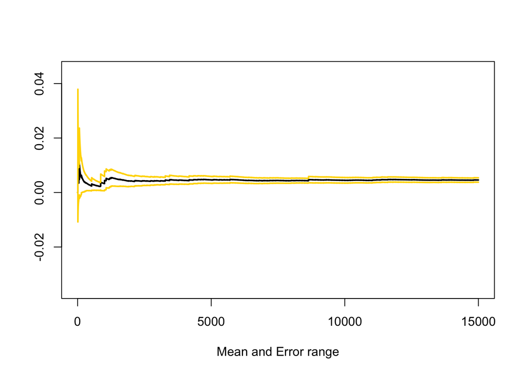

```r
plot(est.int, xlab = "Mean and Error range", ylab = "", type = "l", lwd = 2, ylim = mean(h_x.result_vec.c)+100*est.err[15000]*c(-1,1))
lines(est.int + 2*est.err, col = "gold", lwd = 2)
lines(est.int - 2*est.err, col = "gold", lwd = 2)
```

## d

```r
theta.f <- 0.005
theta.g <- 0.02

h_x.result_vec.d <- numeric(50000)

for (i in 1:50000) {
  graph.zero_day.i <- make_graph(c("A", "B", "A", "C","A", "D","A", "E",
                           "B","C","B","F",
                           "C","F","C","G","C","D","C","H",
                           "D","E","D","H","D","I","D","G",
                           "E","I",
                           "F","G","F","J",
                           "G","H","G","J",
                           "H","I","H","J",
                           "I","J"), directed = TRUE)
  after_10_days.i <- rbinom(n = 22,size = 1,prob = 1-exp(-10*theta.g))
  graph_after_10_days.i <- delete.edges(graph = graph.zero_day.i,edges = which(after_10_days.i==1))
  paths_A_J_after_10_days.i <- all_simple_paths(graph = graph_after_10_days.i,from = "A","J")
  if(identical(paths_A_J_after_10_days.i,list())){
    h_x.result_vec.d[i] <- 1*prod( dbinom(x = after_10_days.i,size = 1,prob = 1-exp(-10*theta.f)) / dbinom(x = after_10_days.i,size = 1,prob = 1-exp(-10*theta.g)))
  }

}
```

```
## Expected value estimator = 2.7776796716378e-05
## Varinace estimator = 1.27083955599586e-06
```

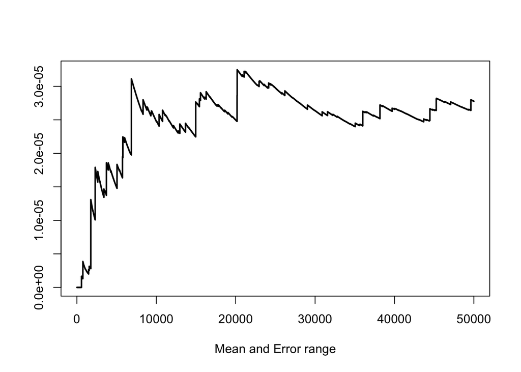

```r
est.int <- cumsum(h_x.result_vec.d)/(1:50000)
est.err <- sqrt( cumsum( (h_x.result_vec.d-est.int)^2 )) / (1:50000)

plot(est.int, xlab = "Mean and Error range", ylab = "", type = "l", lwd = 2)
```

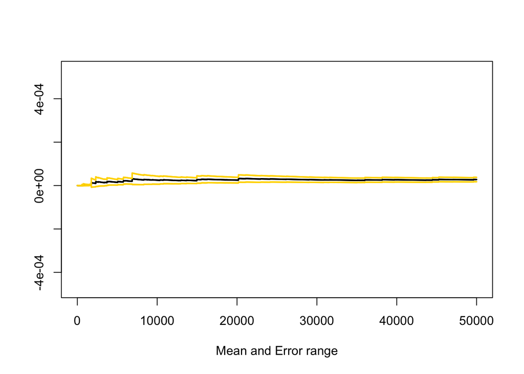

```
##                                    A           B           C           D
## Expected value estimator 0.004466667 4.00000e-05 0.004596683 2.77768e-05
## Varinac value estimator  0.004447012 3.99992e-05 0.002433420 1.27084e-06
```

```r
plot(est.int, xlab = "Mean and Error range", ylab = "", type = "l", lwd = 2, ylim = mean(h_x.result_vec.d)+100*est.err[50000]*c(-1,1))
lines(est.int + 2*est.err, col = "gold", lwd = 2)
lines(est.int - 2*est.err, col = "gold", lwd = 2)
```

It can be seen that the difference between section A and section B is that when the probability of system failure is so low, it is more “expensive” to sample and get a “good” estimation for expectation. When in sections C and D we used “IS” method, we actually sampled from a similar distribution but with a larger parameter. That is, we have created a situation where there is a greater chance of seeing a system failure. As a result, the samples were “cheaper”. This can be seen by looking at the variance estimations: IS’s variance estimations are significantly smaller than the non-IS variance estimations.

# Q2

## a

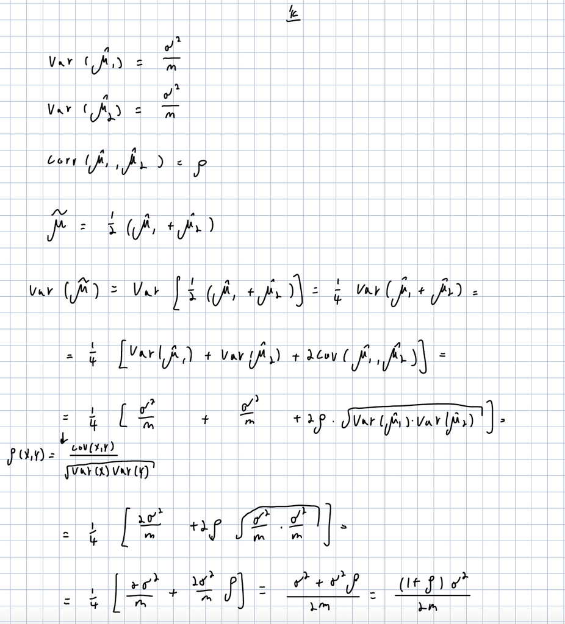

## b

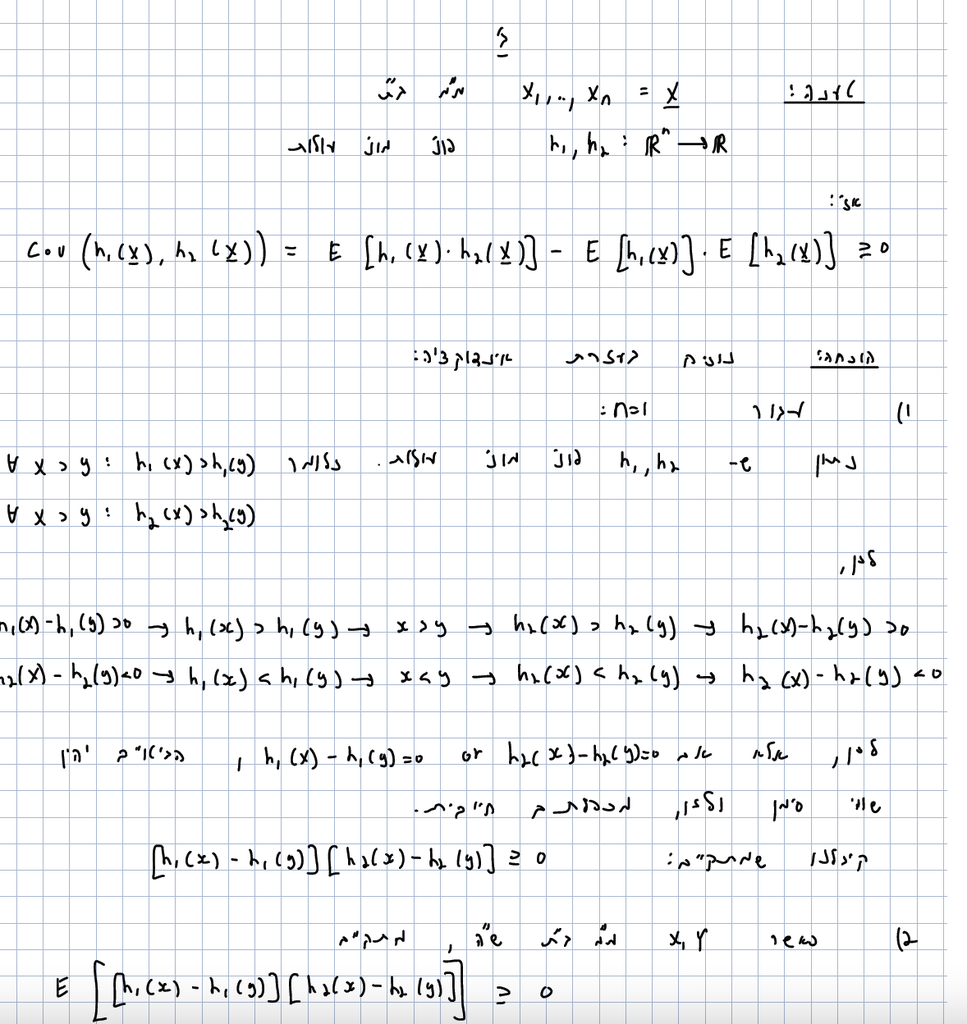

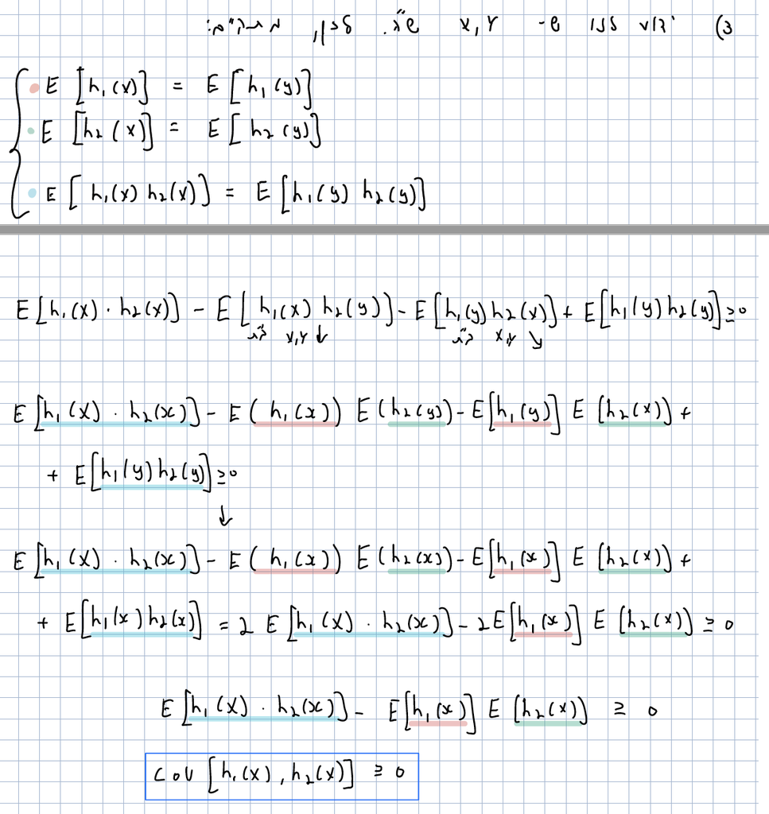

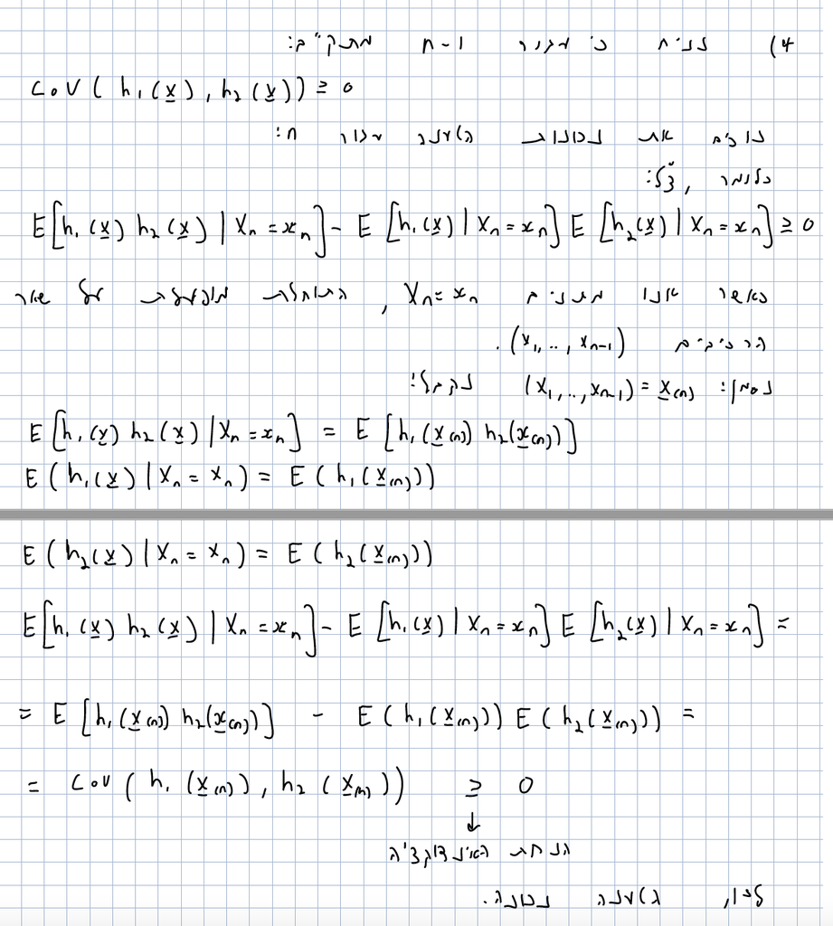

## c

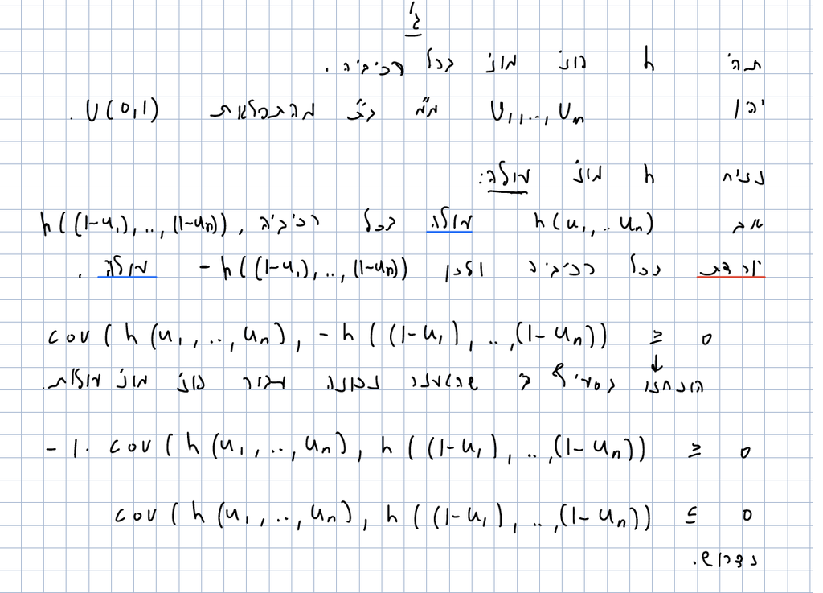

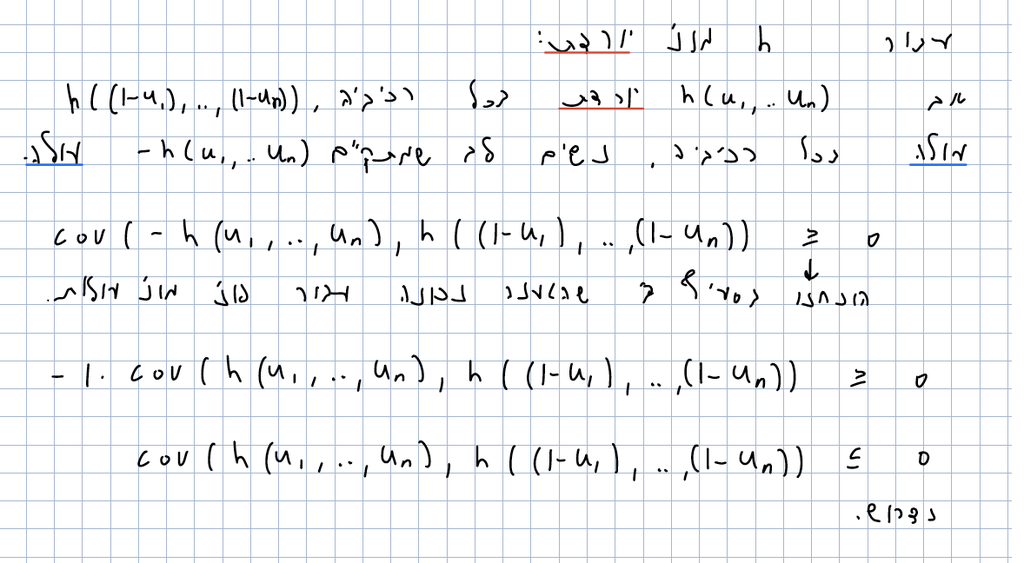

## d

### d.1

h(u) = -log(1-u)/theta

u gets values between 0 and 1.

So, (1-u) gets smaller values as u increases.

Giving a small value to a log function gets a smaller value and multiplying by minus 1/theta gives us a larger value (we know theta is positive).

Therefore, our function is a monotonically increasing function in u values.

```r
theta <- 0.02

h_x.result_vec.2.d <- numeric(15000)

for (i in 1:15000) {
  graph.zero_day.i <- make_graph(c("A", "B", "A", "C","A", "D","A", "E",
                           "B","C","B","F",
                           "C","F","C","G","C","D","C","H",
                           "D","E","D","H","D","I","D","G",
                           "E","I",
                           "F","G","F","J",
                           "G","H","G","J",
                           "H","I","H","J",
                           "I","J"), directed = TRUE)
  u_vec <- runif(22)
  after_10_days.i <- -log(1-u_vec)/theta # we sample from the exp(theta) distribution using the inverse function
  graph_after_10_days.i <- delete.edges(graph = graph.zero_day.i,edges = which(after_10_days.i<=10))
  paths_A_J_after_10_days.i <- all_simple_paths(graph = graph_after_10_days.i,from = "A","J")
  if(identical(paths_A_J_after_10_days.i,list())){
    h_x.result_vec.2.d[i] <- 1
  }

}
```

### d.2

we will use antithetic sampling by using the following h functions:

- h(u) = -log(1-u)/theta - Monotonically increasing function in u values.
- h(1-u) = -log(1-(1-u))/theta = -log(u)/theta - Monotonically decreasing function in u values.

```r
theta <- 0.02

h_x.result_vec.2.d.inc <- numeric(15000)
h_x.result_vec.2.d.dec <- numeric(15000)

for (i in 1:15000) {
  graph.zero_day.i <- make_graph(c("A", "B", "A", "C","A", "D","A", "E",
                           "B","C","B","F",
                           "C","F","C","G","C","D","C","H",
                           "D","E","D","H","D","I","D","G",
                           "E","I",
                           "F","G","F","J",
                           "G","H","G","J",
                           "H","I","H","J",
                           "I","J"), directed = TRUE)
  u_vec <- runif(22)

  after_10_days.i.inc <- -log(1-u_vec)/theta
  after_10_days.i.dec <- -log(u_vec)/theta

  graph_after_10_days.i.inc <- delete.edges(graph = graph.zero_day.i,edges = which(after_10_days.i.inc<=10))
  graph_after_10_days.i.dec <- delete.edges(graph = graph.zero_day.i,edges = which(after_10_days.i.dec<=10))

  paths_A_J_after_10_days.i.inc <- all_simple_paths(graph = graph_after_10_days.i.inc,from = "A","J")
  paths_A_J_after_10_days.i.dec <- all_simple_paths(graph = graph_after_10_days.i.dec,from = "A","J")


  if(identical(paths_A_J_after_10_days.i.inc,list())){
    h_x.result_vec.2.d.inc[i] <- 1
  }
  if(identical(paths_A_J_after_10_days.i.dec,list())){
    h_x.result_vec.2.d.dec[i] <- 1
  }

}
```

```r
A_S_expected_value_estimator <- 0.5*(mean(h_x.result_vec.2.d.inc) + mean(h_x.result_vec.2.d.dec))
A_S_varinace_estimator <- (var(h_x.result_vec.2.d.inc) + var(h_x.result_vec.2.d.dec) + 2*cov(h_x.result_vec.2.d.inc,h_x.result_vec.2.d.dec))/4
```

```
## Antithetic sampling expected value estimator = 0.0058
## Antithetic sampling varinace estimator = 0.0029
```

#### Comparison between Antithetic sampling estimator and Importance sampling:

[output not shown]

### d.3

#### Antithetic sampling estimator

```r
x_norm_vec <- rnorm(10000)
h_x_plus <- (exp(x_norm_vec) + 7)^(x_norm_vec/3)
h_x_minus <- (exp(-x_norm_vec) + 7)^(-x_norm_vec/3)

A_S_expected_value_estimator_d3 <- 0.5*(mean(h_x_plus)+mean(h_x_minus))
A_S_varinace_estimator_d3 <- (var(h_x_plus) + var(h_x_minus) + 2*cov(h_x_plus,h_x_minus)) / 4
```

#### Monte Carlo estimator

```r
h_x_monte_carlo <- (exp(x_norm_vec) + 7)^(x_norm_vec/3)

MC_expected_value_estimator_d3 <- mean(h_x_monte_carlo)
MC_varinace_estimator_d3 <- var(h_x_monte_carlo)
```

```
## Antithetic sampling expected value estimator = 1.574
## Antithetic sampling varinace estimator = 11.4832
## Monte Carlo expected value estimator = 1.5725
## Monte Carlo varinace estimator = 24.5819
```

```
## We got that the variance of antithetic sampling estimator is = 2.1 times smaller than the monte carlo estimator
```